# ポアンカレ ディスク

## 双曲面模型

この節は、[Hyperboloid model(Wikipedia記事)](https://en.wikipedia.org/wiki/Hyperboloid_model) に従って書いてある。

双曲面模型とは、n+1次元空間にある、ある(超)双曲面上の点を、n次元空間中の単位球体(円板)にあるルールで射影するもの。

n+1次元空間は、ミンコフスキー空間になっており、内積の定義に負の固有値が入っているため、直線・平行線・距離の概念がユークリッド空間のそれとは異なっている。

ミンコフスキー空間のm+1次元(超)平面は、n次元平面に射影されてm次元(超)平面になるが、それは、n+1次元空間の超平面が、双曲面とよぎった点の写像としてあらわされる。

n=2の場合は、ミンコフスキー空間は３次元、射影は２次元円板、ミンコフスキー空間の平面が、ミンコフスキー空間の双曲面とよぎって、３次元空間上の曲線となり、その写像が、２次元円板上の曲線となる。

$$x^2 + y^2 - z^2 \le 0; z \ge 0$$
の領域を考える。

この空間に
$$x^2 + y^2 - z^2 = -1$$
という双曲面がある。

### 3次元ミンコフスキー空間座標の単位円板への射影

その領域の点(x,y,z)を、$z=0$平面上の半径１の円板$x^2 + y^2 \le 1$上に射影することとする。

点(0,0,-1)と(x,y,z)とを通る直線が、$z=0$をよぎる点の座標(x’,y’,0)は 以下の式で与えられる。

$$x' = \frac{x}{z+1}\\
y' = \frac{y}{z+1}$$

逆写像は、次の式で与えられる。

$$x = \frac{2x'}{1-x'^2-y'^2}\\
y = \frac{2y'}{1-x'^2-y'^2}\\
z = \frac{1+x'^2+y'^2}{1-x'^2-y'^2}$$

```r
my.pdisk.coords <- function(x){
  x. <- x[1]/(x[3]+1)
  y. <- x[2]/(x[3]+1)
  return(c(x.,y.))
}
# 円板上の点の座標をx^2 + y^2 - z^2 = -1 という双曲面上に逆写像する
my.pdisk.coords.inv <- function(x){
  z <- (1+sum(x^2))/(1-sum(x^2))
  tmp <- 2*x/(1-sum(x^2))
  return(c(tmp,z))
}
#my.pdisk.coords.inv_bk <- function(x){
#  tmp <- x/sqrt(1-sum(x^2))
#  z <- sqrt(sum(tmp^2)+1)
#  return(c(tmp,z))
#}
# x^2+y^2-z^2=0という円錐に逆写像
#my.pdisk.coords.inv.cone <- function(x){
#  k <- (-1+sqrt(sum(x^2)))/(sum(x^2)-1)
#
#  return(k * c(x,1))
#}
```

### 双曲面上の点の射影

```r
n <- 10000
x <- runif(n,min=-10,max=10)
y <- runif(n,min=-10,max=10)
z <- sqrt(x^2 + y^2 + 1)

xyz <- cbind(x,y,z)
```

```r
plot3d(xyz)
```

[interactive chart not shown]

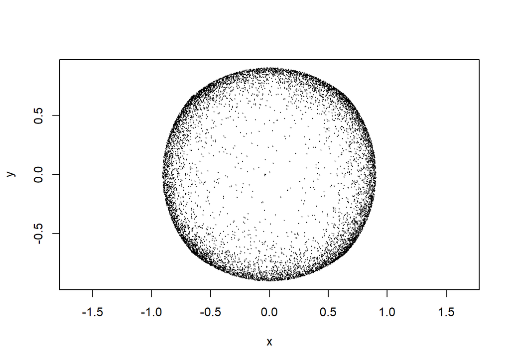

```r
pd.crd <- apply(xyz,1,my.pdisk.coords)
plot(t(pd.crd),pch=20,cex=0.1,asp=TRUE)
```

双曲面の外側にいくほど、円板上で点が密になる。

円板上では、短い距離にみえても、ミンコフスキー空間上では遠い距離に相当するからである。

### ミンコフスキー内積と点間の双曲幾何的距離

ベクトルの長さのようなもの(二次形式)が以下のように与えられているとき、
$$Q(x_1,x_2,...) = -(x_1^2+...+x_{n}^2) + x_{n+1}^2$$

双曲面は$Q(x_1,...) = 1$上の点の集まりのことである。

この双曲面上の２点に相当するベクトル$u,v$があったとき、その内積は

$$<u,v> = \frac{Q(u+v) - (Q(u)+Q(v))}{2} = -(u_1v_2 + ... + u_n v_n) + u_{n+1}v_{n+1}$$
で与えられる。

この２点の双曲幾何的距離は
$$d(u,v) = arcosh(<u,v>)$$

### 距離を視覚化

単位円板上に点を取り、そのうちのある１点からの双曲幾何的距離を視覚化してみる。

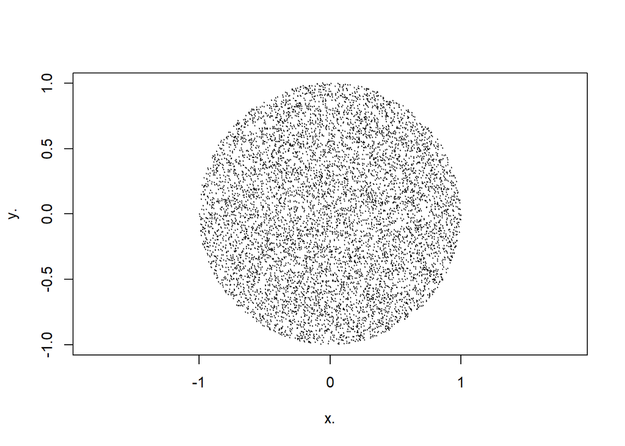

```r
n <- 10000
x. <- runif(n,min=-1,max=1)
y. <- runif(n,min=-1,max=1)
r2 <- x.^2 + y.^2
s <- which(r2 < 1)
x. <- x.[s]
y. <- y.[s]
plot(x.,y.,pch=20,cex=0.1,asp=TRUE)
```

```r
hyp.cds <- t(apply(cbind(x.,y.),1,my.pdisk.coords.inv))
plot3d(hyp.cds)
```

[interactive chart not shown]

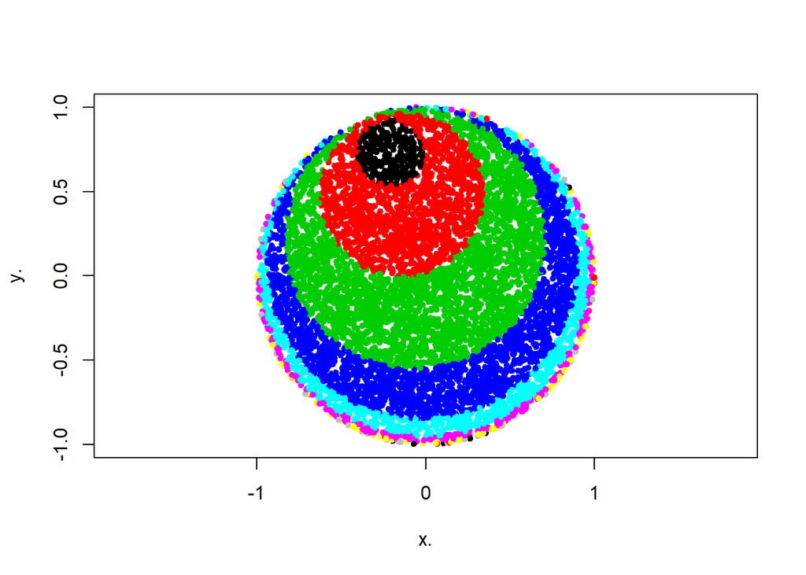

```r
my.hyp.dist <- function(u,v){
  acosh(- sum(u*v) + 2*u[length(u)]*v[length(v)])
}
d <- apply(hyp.cds,1,my.hyp.dist,hyp.cds[1,])
col <- ceiling(d/max(d)*10)
plot(x.,y.,pch=20,cex=1,asp=TRUE,col=col)
```

### 直線・測地戦

双曲幾何的直線は、双曲面と３次元平面との交わり。

$$<u,u> = -1\\
<v,v> = 1\\
<u,v> = 0$$

という２つのベクトルが、パラメタ$w$を用いて
$$u \cosh{w} + v \sinh{w}$$
で表される点がそうなるのだと言う。

$u = (u_1,u_2,u_3),v = (v_1,v_2,v_3)$のうち、$u_1,u_2,v_1$を指定し残り３変数を計算する関数を以下のように作る。

上記の制約を満足する$v_2,v_3$の取り方は４通りあるが、そのうち、双曲面上の曲線となるのは、以下に示すように２通り。

点$u$は、双曲面上の点、点$v$はベクトル$uv$が双曲面の接面となるような点

```r
my.hyp.line.vec <- function(u1,u2,v1){
  u3 <- sqrt(u1^2+u2^2+1)
  tmp <- sqrt(u1^2*v1^2*u2^2 + (u1^2+v1^2+1)*(u1^2+u2^2+1))
  v2a <- (u1*v1*u2 + tmp )/(u1^2+v1^2+1)
  v2b <- (u1*v1*u2 - tmp )/(u1^2+v1^2+1)
  u <- c(u1,u2,u3)
  v3a <- sqrt(v1^2+v2a^2-1)
  v3b <- sqrt(v1^2+v2b^2-1)
  va <- c(v1,v2a,v3a)
  va. <- c(v1,v2a,-v3a)
  vb <- c(v1,v2b,v3b)
  vb. <- c(v1,v2b,-v3b)
  return(list(u=u,va=va,va.=va.,vb=vb,vb.=vb.))
}
```

```r
u1 <- 0.5
u2 <- 0.7
v1 <- -0.3
uv <- my.hyp.line.vec(u1,u2,v1)
uv
```

```
## $u
## [1] 0.500000 0.700000 1.319091
##
## $va
## [1] -0.3000000  1.0638534  0.4709397
##
## $va.
## [1] -0.3000000  1.0638534 -0.4709397
##
## $vb
## [1] -0.30000 -1.22057  0.76144
##
## $vb.
## [1] -0.30000 -1.22057 -0.76144
```

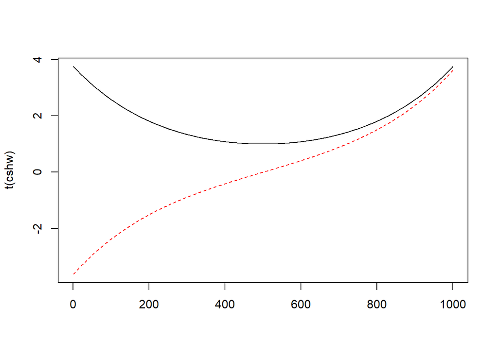

```r
w <- seq(from=-2,to=2,length=1000)
coshw <- cosh(w)
sinhw <- sinh(w)
cshw <- rbind(coshw,sinhw)
matplot(t(cshw),type="l")
```

```r
u <- uv$u
va <- uv$va
va.  <- uv$va.
vb <- uv$vb
vb. <- uv$vb.

lina <- cbind(u,va) %*% cshw
lina. <- cbind(u,va.) %*% cshw

linb<- cbind(u,vb) %*% cshw
linb. <- cbind(u,vb.) %*% cshw
```

[interactive chart not shown]

```r
n <- 10000
x <- runif(n,min=-2,max=2)
y <- runif(n,min=-2,max=2)
z <- sqrt(x^2 + y^2 + 1)

xyz <- cbind(x,y,z*sample(c(-1,1),n,replace=TRUE))

plot3d(xyz)
spheres3d(t(lina ),radius=0.05,col=2)
spheres3d(t(lina. ),radius=0.05,col=3) # 双曲面に乗らない
spheres3d(t(linb ),radius=0.05,col=4) # 双曲面に乗らない
spheres3d(t(linb. ),radius=0.05,col=5) #
spheres3d(u,radius=0.1,col=6)
spheres3d(va,radius=0.1,col=2)
spheres3d(va.,radius=0.1,col=3)
spheres3d(vb,radius=0.1,col=4)
spheres3d(vb.,radius=0.1,col=5)
segments3d(rbind(rep(0,3),u))

segments3d(rbind(rep(0,3),va))
segments3d(rbind(rep(0,3),va. ))

segments3d(rbind(rep(0,3),vb ))
segments3d(rbind(rep(0,3),vb. ))
```

[interactive chart not shown]

この直線を単位円板に射影する。

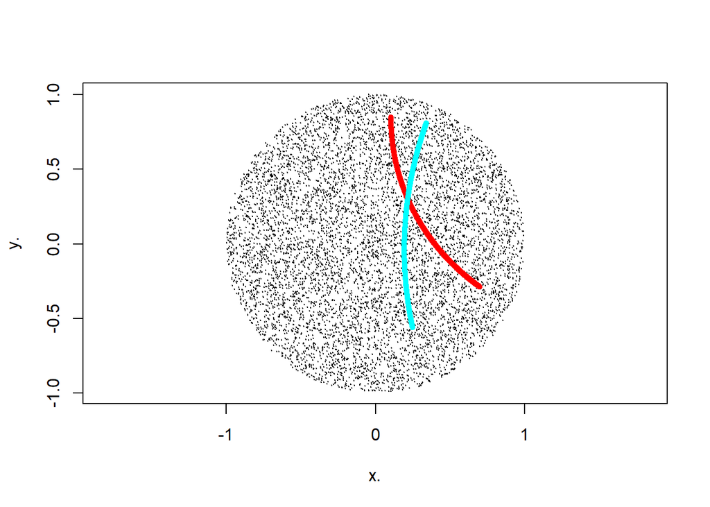

```r
n <- 10000
x. <- runif(n,min=-1,max=1)
y. <- runif(n,min=-1,max=1)
r2 <- x.^2 + y.^2
s <- which(r2 < 1)
x. <- x.[s]
y. <- y.[s]
plot(x.,y.,pch=20,cex=0.01,asp=TRUE)

pd.crd.a  <- apply(t(lina ),1,my.pdisk.coords)
points(t(pd.crd.a),pch=20,cex=1,col=2)
pd.crd.b.  <- apply(t(linb. ),1,my.pdisk.coords)
points(t(pd.crd.b.),pch=20,cex=1,col=5)
```

## ポアンカレ・ディスク

この節は[Poincare Disk model (Wikipedia記事)](https://en.wikipedia.org/wiki/Poincar%C3%A9_disk_model) に従てって書いている。

### 直線

単位円板の辺縁の点と直交するすべてのユークリッド幾何の意味での円周は、双曲幾何での直線に相当する。

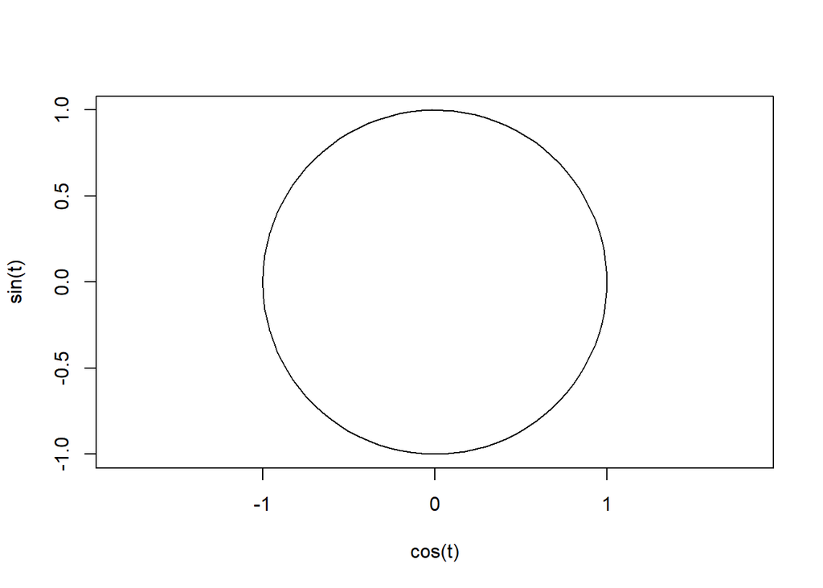

```r
t <- seq(from=0,to=1,length=100)*2*pi
plot(cos(t),sin(t),type="l",asp=1)
```

単位円板のある点$(\cos{\theta},\sin{\theta})$を通り、単位円周と直交する円の中心は、 その点を通る、単位円の接線上の点である。

接線の方向ベクトルは$(-\sin{\theta},\cos{\theta})$であるから、

そのような円の座標は
$$ctr_x = \cos{\theta} - r \sin{\theta}\\
ctr_y = \sin{\theta} + r \cos{\theta}$$
であり、その半径は、$r$である。

```r
# 円周上の点座標ptと直交円の半径rを与え
# 中心を返す関数
my.orth.circle1 <- function(pt,r){
  ctr_x <- pt[1] - r * pt[2]
  ctr_y <- pt[2] + r * pt[1]
  return(c(ctr_x,ctr_y))
}
```

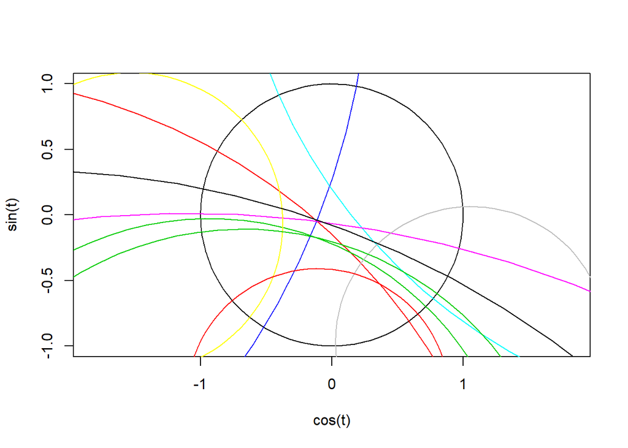

```r
plot(cos(t),sin(t),type="l",asp=1)

n.line <- 10

for(i in 1:n.line){
  theta <- runif(1) * 2 * pi
  r <- 10^runif(1)
  ctr <- my.orth.circle1(c(cos(theta),sin(theta)),r)

  pnts <- cbind(r*cos(t)+ctr[1],r*sin(t)+ctr[2])
  points(pnts,type="l",col=i+1)
}
```

#### Inversion 反転を使う方法

平面上の任意の２点を通る円で、単位円と直交するものを求める。

ある点がその円周上にあるとき、その点を単位円に関して反転した点も通ることを利用する。

```r
my.inversion <- function(x){
  r <- sqrt(sum(x^2))
  R <- 1/r
  return(x/r*R)
}
# P, Qは任意の２点の座標
my.orth.circle2 <- function(P,Q){
  P. <- my.inversion(P)
  Q. <- my.inversion(Q)
  M <- (P + P.)/2
  N <- (Q + Q.)/2

  k. <- (M[1]^2+M[2]^2-M[1]*N[1]-M[2]*N[2])/(M[1]*N[2]-M[2]*N[1])
  ctr_x <- N[1] + k.*N[2]
  ctr_y <- N[2] - k.*N[1]
  r <- sqrt((ctr_x-P[1])^2+(ctr_y-P[2])^2)

  return(list(ctr=c(ctr_x,ctr_y),r=r,P=P,Q=Q,P.=P.,Q.=Q.))
}
```

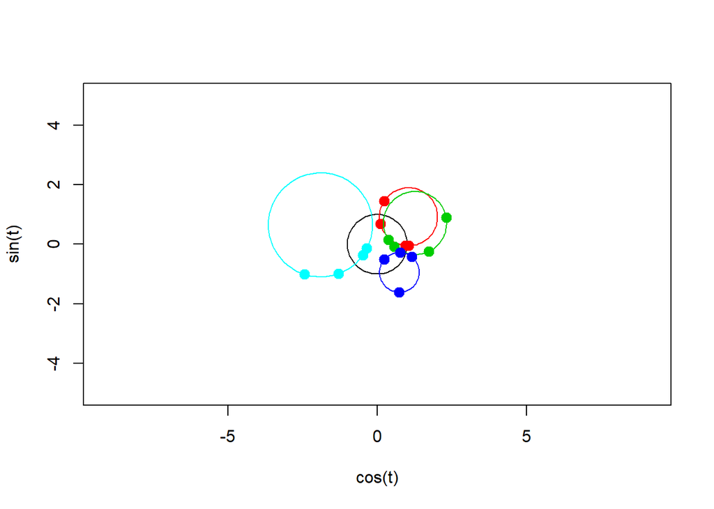

```r
plot(cos(t),sin(t),type="l",asp=1,xlim=c(-5,5),ylim=c(-5,5))

n.line <- 4

for(i in 1:n.line){
  P <- rnorm(2) * 1
  Q <- rnorm(2) *1
  #P <- c(2,0)
  #Q <- c(0,2)
  tmp <- my.orth.circle2(P,Q)
  r <- tmp$r
  ctr <- tmp$ctr
  pnts <- cbind(r*cos(t)+ctr[1],r*sin(t)+ctr[2])
  points(pnts,type="l",col=i+1)
  points(P[1],P[2],col=i+1,pch=20,cex=2)
  points(Q[1],Q[2],col=i+1,pch=20,cex=2)
  points(tmp$P.[1],tmp$P.[2],col=i+1,pch=20,cex=2)
  points(tmp$Q.[1],tmp$Q.[2],col=i+1,pch=20,cex=2)
}
```

### 距離

上記で描いた、ポアンカレ・ディスク上の曲線が測地線。 測地戦をたどって「距離」を測る。

円板内の２点を通る測地線を延ばして円周との交点を取る。

順番に、A,P,Q,B(A,Bは円周上の点、P,Qは円板内の点)とする。

双曲幾何的なPQ距離$d_{hyp}(P,Q)$は、ユークリッド的距離$|XY|$を使って、以下のように定まる。

$$d_{hyp}(P,Q) = \log{\frac{|AQ||PB|}{|AP||QB|} }$$

Pが円周上に近づくと、AP間のユークリッド距離が0に近づくので、上の式の分母が0に近づき、分数自体は無限大に向かう。

逆に、PとQとが近づくと、分数が1に近づくので、双曲幾何的距離も0に近づく。

２つの方法で計算して結果を比較してみる。

```r
my.hyp.dist1 <- function(P,Q){
  out <- my.orth.circle2(P,Q)
  r <- out$r
  d.ctr <- sqrt(sum(out$ctr^2)) # 原点から測地線円の中心までの距離
  theta <- acos(1/d.ctr)
  phi <- Arg(out$ctr[1] + 1i * out$ctr[2]) # 測地線円方向の角度
  AB1 <- c(cos(phi-theta),sin(phi-theta))
  AB2 <- c(cos(phi+theta),sin(phi+theta))

  AQ <- sqrt(sum((AB1-Q)^2))
  PB <- sqrt(sum((P-AB2)^2))
  AP <- sqrt(sum((AB1-P)^2))
  QB <- sqrt(sum((Q-AB2)^2))
  # A,BをAB1,AB2のどちらにするか、２通りで距離を算出する
  dhyp1 <- log(AQ*PB/(AP*QB))
  dhyp2 <- log(QB*AP/(PB*AQ))

  return(list(dhyp1=dhyp1,dhyp2=dhyp2,A=AB1,B=AB2,circle=out))
}
my.hyp.dist2 <- function(P,Q,r=1){
  #r <- 1
  PQ <- sqrt(sum((P-Q)^2))
  OP <- sqrt(sum((P)^2))
  OQ <- sqrt(sum((Q)^2))

  dhyp <- acosh(1+2*PQ^2*r^2/((r^2-OP^2)*(r^2-OQ^2)))
  return(dhyp)
}
```

```r
r4 <- runif(4)
#r4[3] <- r4[1]+rnorm(1)*0.0001
#r4[4] <- r4[2] + rnorm(1)*0.0001
P <- r4[1] * c(cos(r4[2]*2*pi),sin(r4[2]*2*pi))
Q <- r4[3] * c(cos(r4[4]*2*pi),sin(r4[4]*2*pi))

out1 <- my.hyp.dist1(P,Q)
out2 <- my.hyp.dist2(P,Q)
out1$dhyp1
```

```
## [1] 3.791598
```

```r
out1$dhyp2
```

```
## [1] -3.791598
```

```r
out2
```

```
## [1] 3.791598
```

念のため、測地線円と単位円との交点を描図しておく。

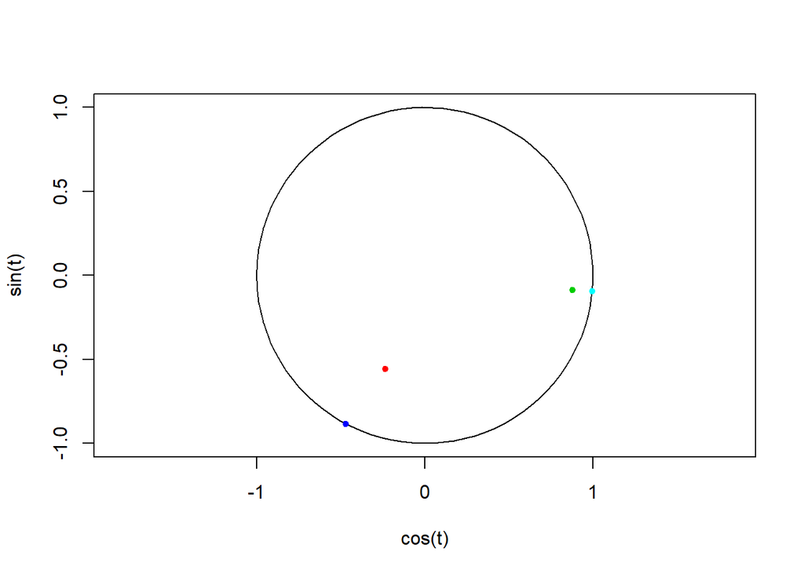

```r
plot(cos(t),sin(t),type="l",asp=1)
points(P[1],P[2],pch=20,col=2)
points(Q[1],Q[2],pch=20,col=3)
points(out1$A[1],out1$A[2],pch=20,col=4)
points(out1$B[1],out1$B[2],pch=20,col=5)
```

ちなみに、双曲線模型では、円盤上の２点間距離を、いったん、双曲面上の座標に戻し、 そこでのミンコフスキー内積を計算し、それに基づいて計算していた。

その方法も再実装する。

```r
my.hyp.dist3 <- function(P,Q){
  P.hyp.cds <- my.pdisk.coords.inv(P)
  Q.hyp.cds <- my.pdisk.coords.inv(Q)
  return(my.hyp.dist(P.hyp.cds,Q.hyp.cds))
}
```

一致することを確認する。

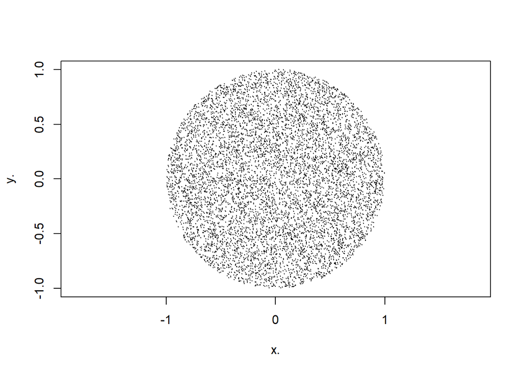

```r
n <- 10000
x. <- runif(n,min=-1,max=1)
y. <- runif(n,min=-1,max=1)
r2 <- x.^2 + y.^2
s <- which(r2 < 1)
x. <- x.[s]
y. <- y.[s]
plot(x.,y.,pch=20,cex=0.01,asp=TRUE)
```

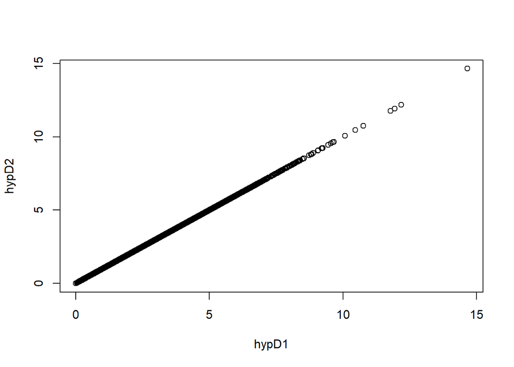

```r
hypD1 <- apply(cbind(x.,y.),1,my.hyp.dist2,c(x.[1],y.[1]))
hypD2 <- apply(cbind(x.,y.),1,my.hyp.dist3,c(x.[1],y.[1]))

plot(hypD1,hypD2)
```

### 円～等距離点集合

ポアンカレ・ディスク上の円は、ある点からの測地線的距離が一定の点の集合。

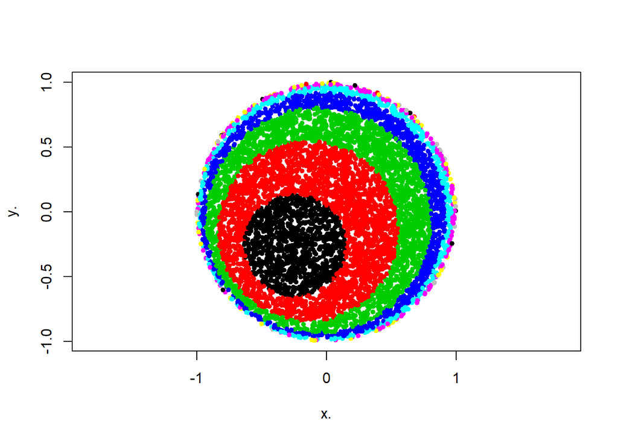

```r
n <- 10000
x. <- runif(n,min=-1,max=1)
y. <- runif(n,min=-1,max=1)
r2 <- x.^2 + y.^2
s <- which(r2 < 1)
x. <- x.[s]
y. <- y.[s]

hypD1 <- apply(cbind(x.,y.),1,my.hyp.dist2,c(x.[1],y.[1]))

col <- ceiling(hypD1/max(hypD1)*10)
plot(x.,y.,pch=20,cex=1,asp=TRUE,col=col)
```

### 円ではないが、円のようなもの

双曲幾何では、いわゆる円の他に、Hypercycle・Hypocycleと言う２つの異なるものが、円と同様に閉じた点集合となる

- 円は、ある点から双曲幾何的距離が等距離の点の集合。
- Hypercycleは双曲幾何的直線から等距離にある点の集合。ただし、点と直線との距離は、直線上の点との距離のうち最小のもののこと。ポアンカレ・ディスクの円周と直交しない円が作る曲線がこれに相当する。
- Hypocycyleは、そのcycleに直行する測地線が漸近的に１点に集まるようなサイクルである。ポアンカレ・ディスクの内部の円で、ディスクに内接する。

### Hypercycle

ある直線から等距離の点の集合は、ユークリッド幾何では、平行な直線になる。 ただし、ユークリッド幾何での平行な直線は、「交点を持たない」直線のことでもある。

双曲幾何では、交わらないことと等距離であることが、同じことにならない。

ある距離を持って等距離な線はある線となり、それは（片側に）１本引けるだけだが、交点を持たない直線は２本以上（たいていは無数に）引ける。

これも視覚化してみよう。

２点を通る測地線を引き、その線との最短距離でディスクを色分けしてみる。

まずは測地線。特に、円板上の点。

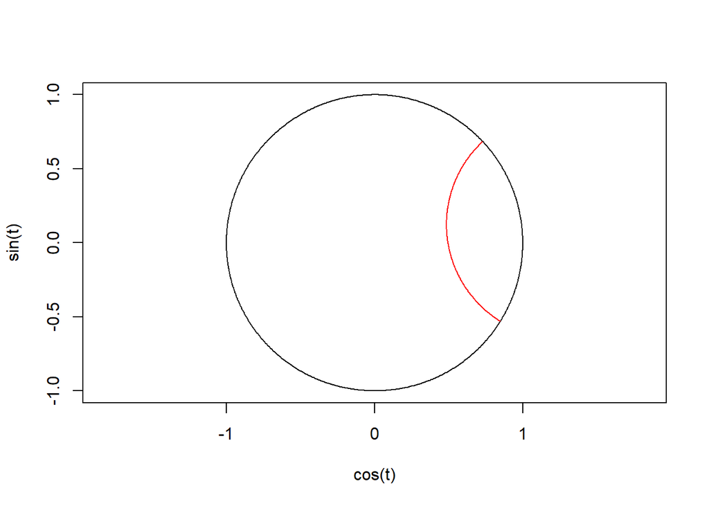

```r
P <- rnorm(2) * 1
Q <- rnorm(2) *1
tmp <- my.orth.circle2(P,Q)
r <- tmp$r
ctr <- tmp$ctr
t <- seq(from=0,to=1,length=1000)*2*pi
pnts <- cbind(r*cos(t)+ctr[1],r*sin(t)+ctr[2])
# このうち、円板上の点のみを選ぶ
s <- which(apply(pnts^2,1,sum) < 1)
pnts <- pnts[s,]
plot(cos(t),sin(t),type="l",asp=1)
points(pnts,type="l",col=2)
```

円板上の乱点と、測地線上の点との双曲幾何的距離を計算し、その中の最小値を取り出す。

```r
n <- 10000
x. <- runif(n,min=-1,max=1)
y. <- runif(n,min=-1,max=1)
r2 <- x.^2 + y.^2
s <- which(r2 < 1)
x. <- x.[s]
y. <- y.[s]

hypD.geod <- matrix(0,length(s),length(pnts[,1]))

for(i in 1:length(pnts[,1])){
  tmp <- apply(cbind(x.,y.),1,my.hyp.dist2,pnts[i,])
  hypD.geod[,i] <- tmp
}
hypD.geod.min <- apply(hypD.geod,1,min)
```

描図すると、測地線からの等距離点集合は円弧をなすが、それは単位円周と直交していないことがわかる。

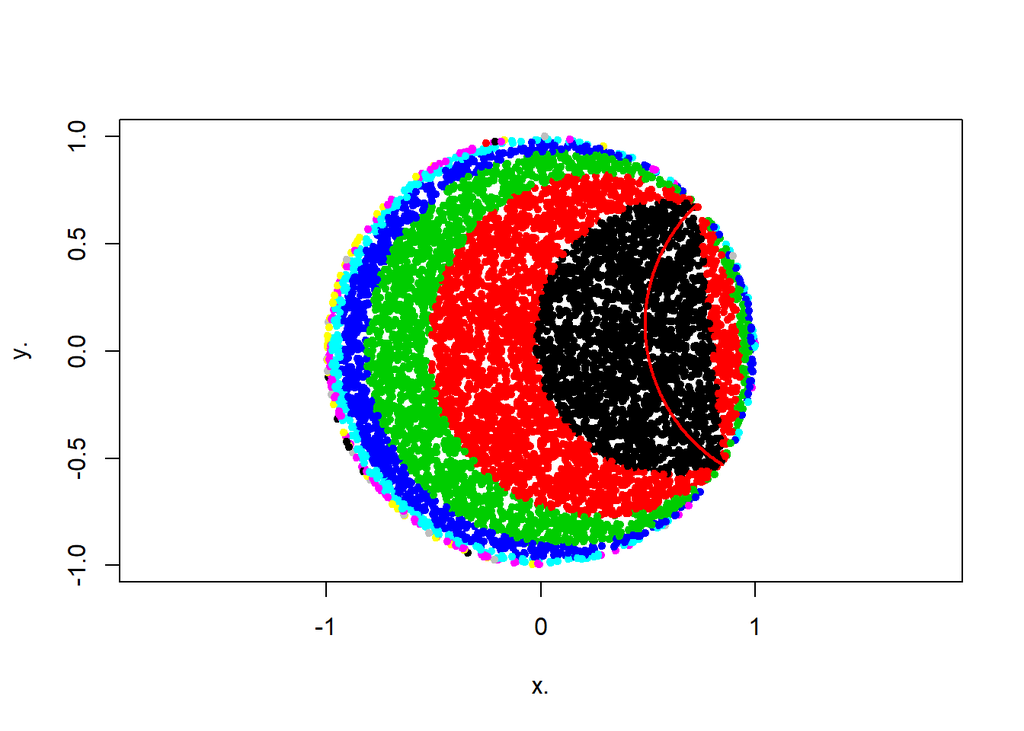

```r
col <- ceiling(hypD.geod.min/max(hypD.geod.min)*10)
plot(x.,y.,pch=20,cex=1,asp=TRUE,col=col)
points(pnts,type="l",col=2,lwd=2)
```

### Hypocycle

可視化してみる。

円周上の点を取り、その点で内接する円を描く。これがHypocycle。

Hypocycle上の任意の点と、内接点とを通る測地線(円)が、Hypocycleと直交していることを示すことで、視覚化したものとする。

Hypocycleがしめしているのは、双曲幾何での直線に直交する直線は、互いに交差することがないが、無限遠では１点に集中する、ということである。

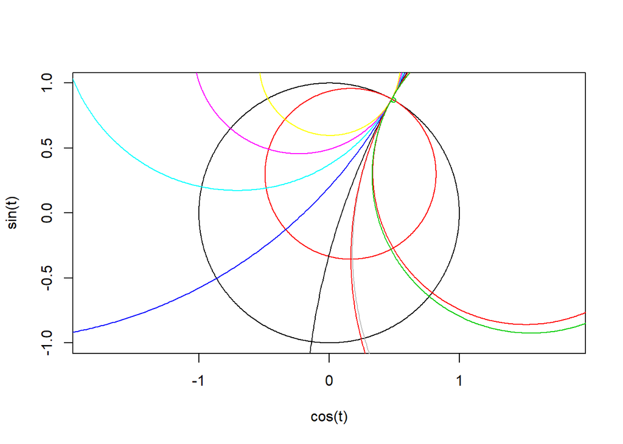

```r
# 内接点を定める角度
theta <- runif(1)*2*pi
# 内接円の半径
r <- runif(1)*0.5 + 0.25
# 内接円の中心座標
ctr <- (1-r) * c(cos(theta),sin(theta))

t <- seq(from=0,to=1,length=1000)*2*pi
pnts <- cbind(r*cos(t)+ctr[1],r*sin(t)+ctr[2])

plot(cos(t),sin(t),type="l",asp=1)
points(pnts,type="l",col=2)

n.line <- 10

t.samples <- sample(1:length(t),n.line)


for(i in 1:n.line){
  P <- c(cos(theta),sin(theta)) # 内接点
  Q <- pnts[t.samples[i],]
  tmp <- my.orth.circle2(P,Q)
  r <- tmp$r
  ctr <- tmp$ctr
  tmp.pnts <- cbind(r*cos(t)+ctr[1],r*sin(t)+ctr[2])
  points(tmp.pnts,type="l",col=i+1)

}
```

## 拡大指数型分布族表現への応用の試み

### 拡大指数型分布族の$\theta$座標推定

２つの正規分布の混合比を１パラメタとする例。

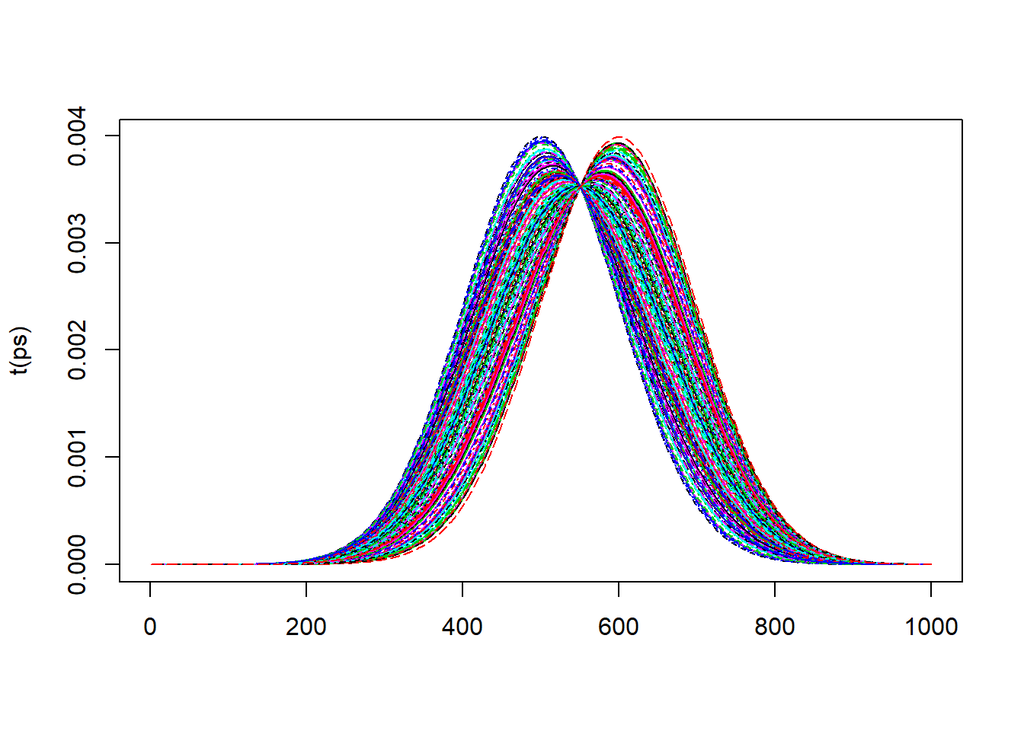

```r
n.sample <- 200
r <- runif(n.sample)
m1 <- 0
sd1 <- 1
m2 <- 1
sd2 <- 1
x <- seq(from=-5,to=5,length=1000)

ps <- matrix(0,n.sample,length(x))
for(i in 1:n.sample){
  ps[i,] <- r[i]*dnorm(x,m1,sd1) + (1-r[i]) * dnorm(x,m2,sd2)
}
ps <- ps/apply(ps,1,sum)
matplot(t(ps),type="l")
```

空間次元１、時間次元１であることが、固有値の様子からわかる。

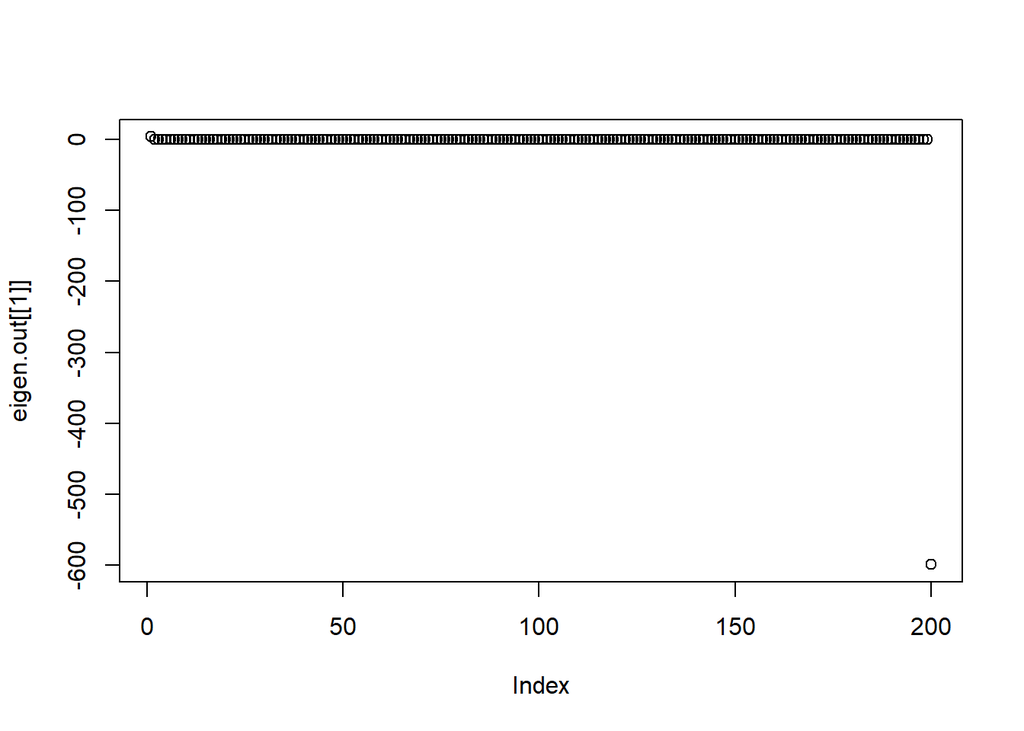

```r
ipmat <- ps %*% t(ps)
logipmat <- log(ipmat)/2
eigen.out <- eigen(logipmat)
plot(eigen.out[[1]])
```

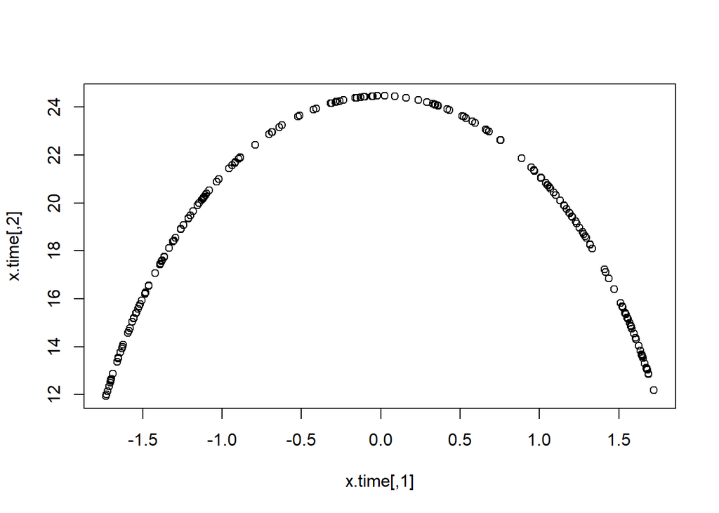

```r
cols <- c(1,length(eigen.out[[1]]))
tmp <- eigen.out[[2]][,cols]
tmp2 <- apply(tmp^2,1,sum)
tmp <- tmp/sqrt(tmp2)
x.time <- t(t(tmp) * sqrt(abs(eigen.out[[1]][cols])))
#x.time <- t(t(eigen.out[[2]][,cols]) * sqrt(abs(eigen.out[[1]][cols])))
# time座標が正になるか負になるかはeigen()関数ではコントロールできないので
# 出力後に正に調整する
x.time[,length(cols)] <- sign(x.time[1,2]) * x.time[,length(cols)]
plot(x.time)
```

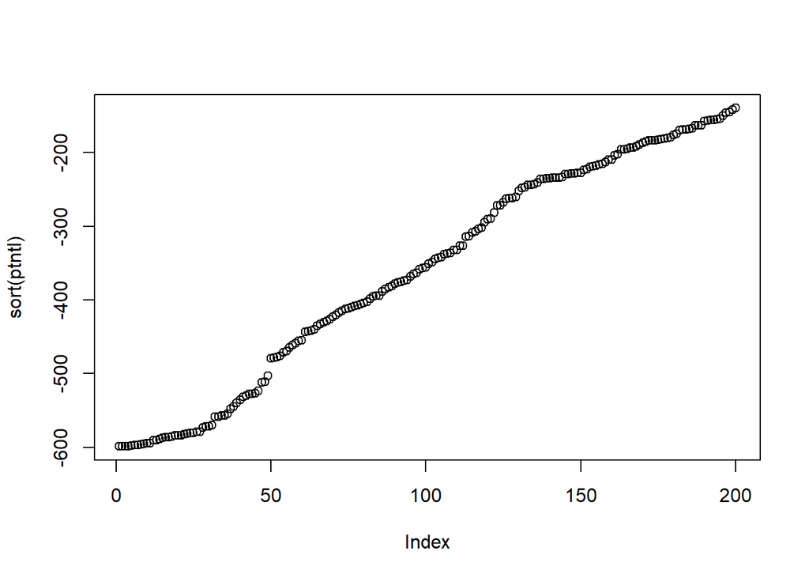

```r
ptntl <- x.time[,1]^2 - x.time[,2]^2
plot(sort(ptntl))
```

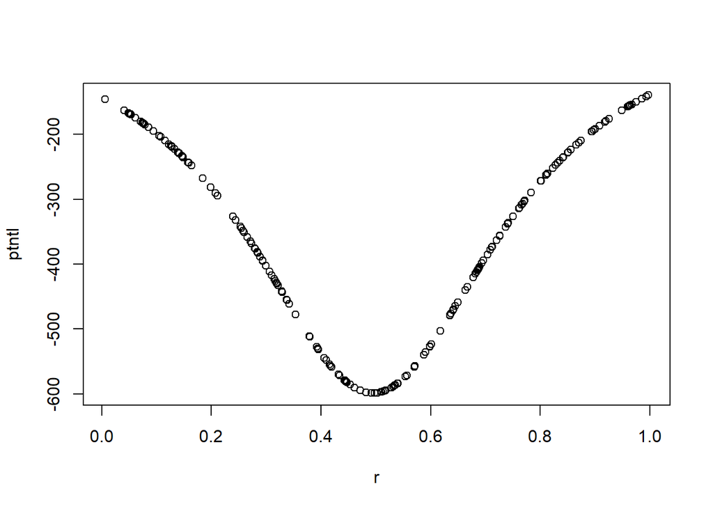

```r
plot(r,ptntl)
```

### ミンコフスキー空間としてとらえる

#### ミンコフスキー空間を双曲面の積み重ねに分解する

この節は、[Minkowski space(Wikipedia記事)のGeometryの節](https://en.wikipedia.org/wiki/Minkowski_space#Geometry)節に に従って書いてある。

ミンコフスキー空間では、n個の正の固有値とm個の負の固有値によってミンコフスキー内積が定まる。

そのうちn=3,m=1のものは、物理学・相対性理論で重要なものであり、資料が多い。

この$M^{n=3,m=1}$では、内積が
$$v_x u_x + v_y u_y + v_z u_z - v_t u_t$$
と計算される。

この空間の各点を距離を保ったままユークリッド空間に埋め込むことはできない。

球面幾何の場合には、次元を一つ上げることで埋め込める（それが球面）のに対して、 双曲幾何では、次元を一つあげてもうまくいかない、ということである。

双曲幾何空間全体を埋め込むことはできないが、双曲幾何空間を

埋め込みのモデルとして、「双曲面モデル」「ポアンカレ・ディスク（ポアンカレ・ボール）モデル」「ポアンカレの半平面モデル」など複数のものが知られている。

この（超）双曲面は、一定負のガウス曲率$-1/R^2$を持った「定負曲率空間」である。

ミンコフスキー空間自体はリーマン多様体ではなく、擬リーマン多様体であるが、（超）双曲面を埋め込んだ各モデルはリーマン多様体になっていて、そのリーマン計量が定まっている。

今、時間軸の座標を$t$、空間軸の座標を$\mathbf(x)$とすると

$$(t,\mathbf{x}) \to \mathbf{u}= \frac{R \mathbf{x}}{(R+t)}\\
\mathbf{u} \to (t,\mathbf{x}) = (R\frac{R^2+|\mathbf{u}|^2}{R^2-|\mathbf{u}|^2},\frac{2R^2 \mathbf{u}}{R^2-|\mathbf{u}|^2})$$

これは、双曲面モデル、ポアンカレ・ディスクモデルのところでは、$R=1$に限定して扱ってきた式の、一般化したものに相当する。

ディスクへの写像座標は(0,-R)と双曲面上の点とを結んだ線によって得られる。

```r
# ベクトルxの最後の座標が時間軸とする
my.pdisk.coords.R <- function(x){
  t <- x[length(x)]
  x. <- x[-length(x)]
  R <- sqrt(-sum(x^2) + 2 * t^2)
  u <- R*x./(R+t)
  return(list(u=u,R=R))
}
my.pdisk.coords.inv.R <- function(u,R){
  t <- R * (R^2+sum(u^2))/(R^2-sum(u^2))
  x. <- 2*R^2*u/(R^2-sum(u^2))
  return(c(x.,t))
}
```

念のため、R=1の例について検算する

```r
x <- 0.4
y <- 0.3
z <- sqrt(x^2+y^2+1)
u1 <- my.pdisk.coords(c(x,y,z))
u2 <- my.pdisk.coords.R(c(x,y,z))
print(u1)
```

```
## [1] 0.1888544 0.1416408
```

```r
print(u2)
```

```
## $u
## [1] 0.1888544 0.1416408
##
## $R
## [1] 1
```

```r
my.pdisk.coords.inv(u1)
```

```
## [1] 0.400000 0.300000 1.118034
```

```r
my.pdisk.coords.inv.R(u2$u,u2$R)
```

```
## [1] 0.400000 0.300000 1.118034
```

#### 指数型分布族表現座標を双曲幾何埋め込み

負の固有値を持つ内積行列で定められた２次元座標をプロットすると、二次曲線様のカーブになっている。

二次関数推定をして実際に、二次曲線であることを確かめる。

２つの正規分布の比率r:(1-r)を0.5:0.5に分けている場合に相当する点を強調して打点しておく。

x=0に相当している。

```r
y <- x.time[,2]
x <- x.time[,1]
model <- lm(y ~ poly(x,2))
print(model)
```

```
##
## Call:
## lm(formula = y ~ poly(x, 2))
##
## Coefficients:
## (Intercept)  poly(x, 2)1  poly(x, 2)2
##     18.5957      -0.0352     -55.7633
```

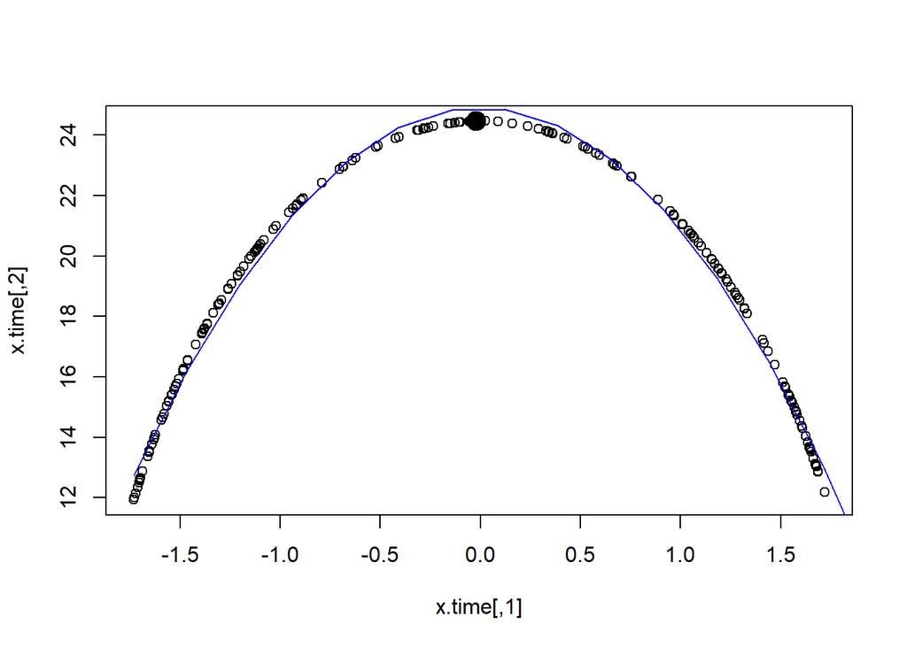

```r
plot(x.time)
abline(0,1)
abline(0,-1)
xx <- seq(from=min(x.time),to=max(x.time),length=100)
lines(xx, predict(model, data.frame(x=xx)), col='blue')
closest05 <- which(abs(r-0.5)==min(abs(r-0.5)))
points(x.time[closest05,1],x.time[closest05,2],pch=20,cex=3)
```

この二次曲線は双曲幾何空間にあると思われるので、それがわかるように、描図範囲と双曲線の漸近直線とを描いた上で、二次曲線を描く。

双曲線の漸近線と交差する二次曲線の（ごく）一部をなしていることが見て取れる。

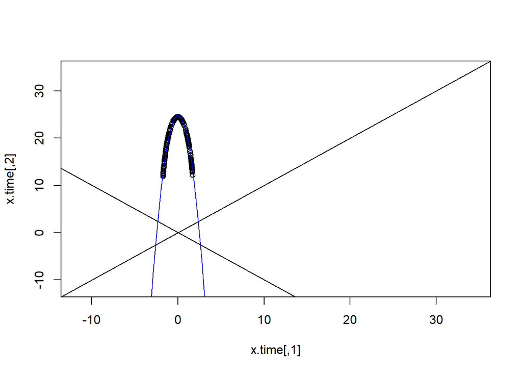

```r
xlim <- range(x.time) + c(-10,10)
ylim <- range(x.time) + c(-10,10)
plot(x.time,xlim=xlim,ylim=ylim)
abline(0,1)
abline(0,-1)
xx <- seq(from=min(x.time)-10,to=max(x.time)+10,length=100)
lines(xx, predict(model, data.frame(x=xx)), col='blue')
```

双曲幾何空間をユークリッド空間的に実現するには、双曲面（双曲線）ごとにモデル（ポアンカレ・ディスクのような）に見立て、異なる双曲面（双曲線）に乗っている点は異なるモデル空間上の点とすることになる。

以下で、それを行う。

Rが双曲線を指定し、 モデル（ここでは、$[-1,1]$線分上の座標を求める。

この座標系では、オリジナルの標本セットの対称性を持った座標系が得られている。

```r
out <- matrix(unlist(apply(sign(x.time[,2])[1]*x.time,1,my.pdisk.coords.R)),ncol=2,byrow=TRUE)
x.poincare <- out[,1]
R <- out[,2]
#out. <- apply(cbind(rep,0,length(x.time[,1]),x.time),1,my.pdisk.coords)
```

比率が0.5:0.5のときにRが最大になっている様子が見て取れる。

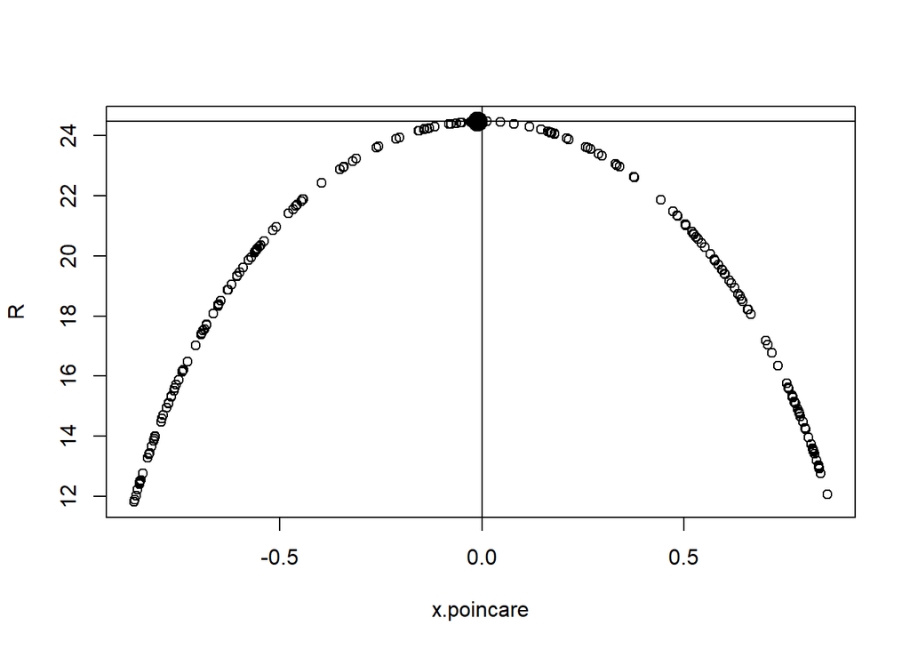

```r
plot(x.poincare,R)
abline(v=0)
abline(h=max(R))
points(x.poincare[closest05],R[closest05],pch=20,cex=3)
```

分布サンプルを発生させるときに用いたパラメタr（２つの正規分布の割合r:(1-r))との関係を図示しておく。

```r
plot3d(cbind(x.poincare,R,r))
```

[interactive chart not shown]

双曲線$x^2-time^2=-R^2$の$R$が判明したので、双曲幾何空間に双曲線を加えて図示してみる。

２つの正規分布の比率が0.5:0.5に一番近い点を強調して表示しておく。

ポアンカレ・ディスク上の点は、(0,-R)と結んだ直線のtime=0との交点。

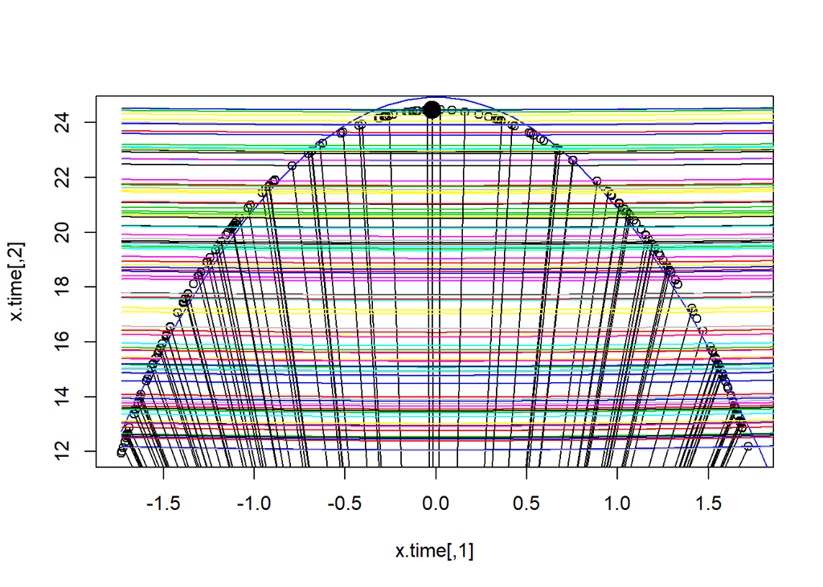

```r
plot(x.time)
abline(0,1)
abline(0,-1)
xx <- seq(from=min(x.time),to=max(x.time),length=500)
lines(xx, predict(model, data.frame(x=xx)), col='blue')

s <- sample(1:length(x.time[,1]),100)
for(i in 1:length(s)){
  this.R <- R[s[i]]
  tt <- sqrt(xx^2+this.R^2) * sign(x.time[1,2])
  lines(xx,tt,col=i+1)
  points(x.poincare[s[i]],0,col=i+1)
  segments(x.time[s[i],1],x.time[s[i],2],0,-this.R)
}

points(x.time[closest05,1],x.time[closest05,2],pch=20,cex=3)
```

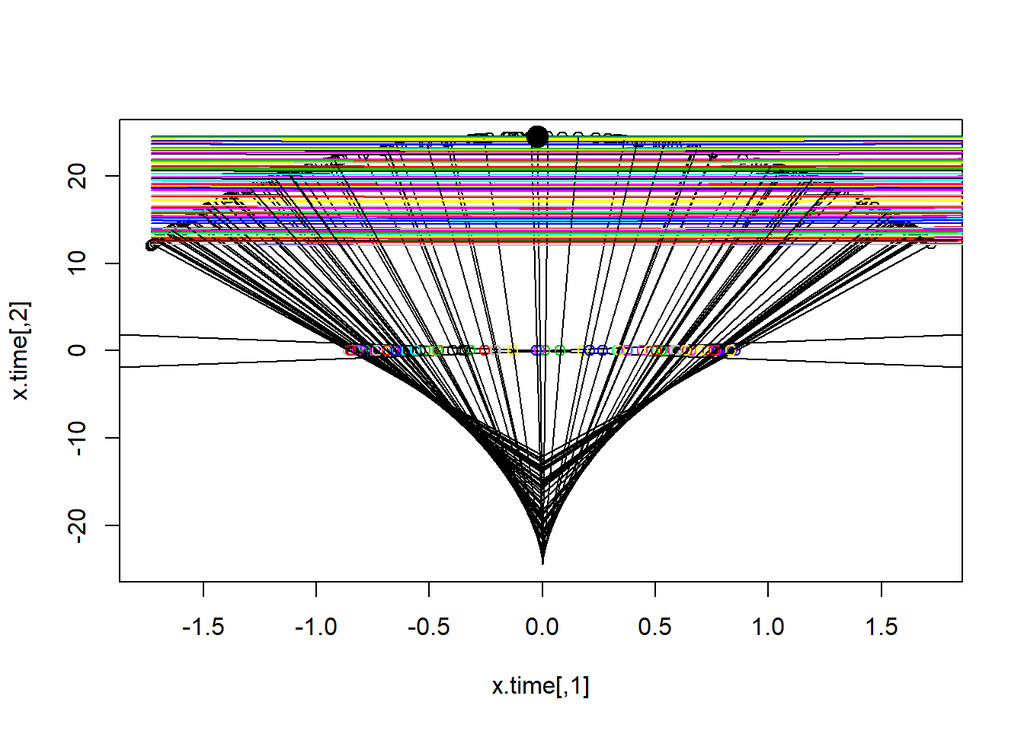

```r
ylim <- c(-max(R),max(x.time[,2]))
plot(x.time,ylim=ylim)
#plot(x.time)
abline(0,1)
abline(0,-1)

for(i in 1:length(s)){
  this.R <- R[s[i]]
  tt <- sqrt(xx^2+this.R^2) * sign(x.time[1,2])
  lines(xx,tt,col=i+1)
  points(x.poincare[s[i]],0,col=i+1)
  segments(x.time[s[i],1],x.time[s[i],2],0,-this.R)
}
closest05 <- which(abs(r-0.5)==min(abs(r-0.5)))
points(x.time[closest05,1],x.time[closest05,2],pch=20,cex=3)
```

この二次曲線は双曲幾何空間にあると思われるので、それがわかるように、描図範囲と双曲線の漸近直線とを描いた上で、二次曲線を描く。

双曲線の漸近線と交差する二次曲線の（ごく）一部をなしていることが見て取れる。

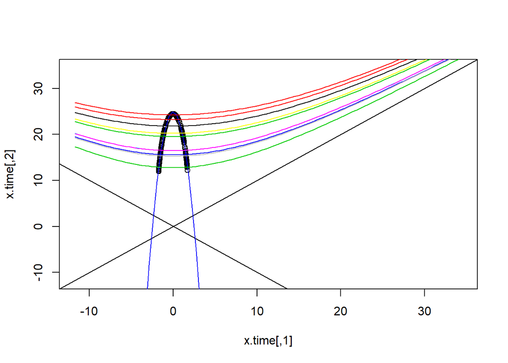

```r
xlim <- range(x.time) + c(-10,10)
ylim <- range(x.time) + c(-10,10)
plot(x.time,xlim=xlim,ylim=ylim)
abline(0,1)
abline(0,-1)
xx <- seq(from=min(x.time)-10,to=max(x.time)+10,length=100)
lines(xx, predict(model, data.frame(x=xx)), col='blue')
s <- sample(1:length(x.time[,1]),10)
for(i in 1:length(s)){
  this.R <- R[s[i]]
  tt <- sqrt(xx^2+this.R^2) * sign(x.time[1,2])
  lines(xx,tt,col=i+1)
}
```